# Assignment # 1 : Data Exploration.

## Data Science 350

This is my first notebook wherein I am exploring the various techniques used by Data scientists to prepare and explore datasets.As this is my first notebook I might be making some assumptions on my part which might not be the standard way of using this very exciting software to share my work.

## About the data set

This data set is from the [Univeristy of California Irving Machine Learning Repository](https://archive.ics.uci.edu/ml/datasets/Energy+efficiency).

- **Source**: The dataset was created by Angeliki Xifara (angxifara '@' gmail.com, Civil/Structural Engineer) and was processed by Athanasios Tsanas (tsanasthanasis '@' gmail.com, Oxford Centre for Industrial and Applied Mathematics, University of Oxford, UK).
- **Data Set Information**: We perform energy analysis using 12 different building shapes simulated in Ecotec. The buildings differ with respect to the glazing area, the glazing area distribution, and the orientation, amongst other parameters. We simulate various settings as functions of the afore-mentioned characteristics to obtain 768 building shapes. The dataset comprises 768 samples and 8 features, aiming to predict two real valued responses. It can also be used as a multi-class classification problem if the response is rounded to the nearest integer.

## Load & examine the data set.

The function shown in the cell below loads the data from the .csv file. I have added three extra columns and one extra row in the original data set with special characters and blanks. Execute the code in this cell to load the data into your notebook. Make sure you have the **.csv file** in your working directory!.

```r
# Clear objects from Memory
rm(list=ls())
# Clear Console:
cat("\014")
source("CleanData.R")

read.energy = function(file = 'EnergyEfficiencyData_1.csv'){
  ## Read the csv file
  energy.eff <- read.csv(file, header = TRUE,
                         stringsAsFactors = FALSE)
}
energy.eff = read.energy()
```

We now look at the data structure of the original data file wherein I have added three extra columns and one extra row in the original data set with special characters and blanks.

```r
#Check out the structure of the original file with added bad columns.
str(energy.eff)
```

```
'data.frame':	769 obs. of  13 variables:
 $ Relative.Compactness     : num  0.98 NA 0.98 0.98 0.98 0.9 0.9 0.9 0.9 0.86 ...
 $ Surface.Area             : num  514 NA 514 514 514 ...
 $ Wall.Area                : num  294 NA 294 294 294 ...
 $ Roof.Area                : num  110 11 110 110 110 ...
 $ Overall.Height           : num  7 12 7 7 7 7 7 7 7 7 ...
 $ BadData_1                : chr  "?" "" "q" "qq" ...
 $ Orientation              : int  2 NA 3 4 5 2 3 4 5 2 ...
 $ Glazing.Area             : num  0 NA 0 0 0 0 0 0 0 0 ...
 $ Glazing.Area.Distribution: int  0 NA 0 0 0 0 0 0 0 0 ...
 $ Heating.Load             : num  15.6 NA 15.6 15.6 15.6 ...
 $ Cooling.Load             : num  21.3 NA 21.3 21.3 21.3 ...
 $ BadData_2                : chr  "?" "" "?" "?" ...
 $ BadData_3                : chr  "#" "" "#" "#" ...
```

## Cleanse the data set.

I am now calling a function "Clean" to do some further cleansing for removal of rows and columns with incomplete information. I am removing any rows wherein special characters ('?', '#', '%') is the only data contained in the columns. This removal of rows is based on the data volume, at this time I remove such rows if its less than 10% of the complete dataset. If above defined special characters are present for more than 90% of the data set, such columns are then removed from the dataset as they do not provide any value to the analysis. I then go on to remove NA's from the dataset.

Execute the code in this cell to load the data into your notebook. Make sure you have the **.csv file** and the **function clean** in your working directory!.

```r
# Cleanse the dataset off special characters (?,%,#)
Cleansedenergy.ff <- Clean(energy.eff)
# Cleanse the data set of NA's
Cleansedenergy.ff<- na.omit(Cleansedenergy.ff)
```

```
Cleansing character  ?
Column BadData_1 contains ? hence 2 rows are being deleted
Column BadData_2 contains 91.15735 % ? hence this column is being deleted

Cleansing character  #
Column BadData_3 contains 90.4824 % # hence this column is being deleted

Cleansing character  %
```

```r
#Check out the structure of the cleansed object.
str((Cleansedenergy.ff))
```

```
'data.frame':	766 obs. of  11 variables:
 $ Relative.Compactness     : num  0.98 0.98 0.98 0.9 0.9 0.9 0.86 0.86 0.86 0.86 ...
 $ Surface.Area             : num  514 514 514 564 564 ...
 $ Wall.Area                : num  294 294 294 318 318 ...
 $ Roof.Area                : num  110 110 110 122 122 ...
 $ Overall.Height           : num  7 7 7 7 7 7 7 7 7 7 ...
 $ BadData_1                : chr  "q" "qq" "qq" "zzz" ...
 $ Orientation              : int  3 4 5 2 4 5 2 3 4 5 ...
 $ Glazing.Area             : num  0 0 0 0 0 0 0 0 0 0 ...
 $ Glazing.Area.Distribution: int  0 0 0 0 0 0 0 0 0 0 ...
 $ Heating.Load             : num  15.6 15.6 15.6 20.8 20.7 ...
 $ Cooling.Load             : num  21.3 21.3 21.3 28.3 25.2 ...
 - attr(*, "na.action")=Class 'omit'  Named int 1
  .. ..- attr(*, "names")= chr "2"
```

Some key things to notice here are:

- We now have 766 rows or observations,original file had 769 observations. Three rows have been deleted as part of cleansing.
- We now have 11 columns, original file has 13 columns, 2 columns have been dropped as part of cleansing.
- We have one character column which I had introduced as bad data and rest are numeric or integers.
- I will now be removing this character column(BadData_1) as it provides no substance to this dataset. It could have been deleted by the function Clean if it was more than 10% of the data set.

```r
#Removing column "BadData_1" as it serves  no purpose in the analysis.
Cleansedenergy.ff$BadData_1 <- NULL
```

### Summary statistics

All the columns are num or integer hence we can calculate the summary of the complete dataset.

Execute the code in the cell below and note the result.

```r
#All the columns are num or integer hence we can calculate the summary of the complete dataset.
lapply(Cleansedenergy.ff, summary)
```

```
$Relative.Compactness
   Min. 1st Qu.  Median    Mean 3rd Qu.    Max.
 0.6200  0.6675  0.7400  0.7637  0.8200  0.9800

$Surface.Area
   Min. 1st Qu.  Median    Mean 3rd Qu.    Max.
  514.5   612.5   686.0   672.1   753.4   808.5

$Wall.Area
   Min. 1st Qu.  Median    Mean 3rd Qu.    Max.
  245.0   294.0   318.5   318.5   343.0   416.5

$Roof.Area
   Min. 1st Qu.  Median    Mean 3rd Qu.    Max.
  110.2   147.0   220.5   176.8   220.5   220.5

$Overall.Height
   Min. 1st Qu.  Median    Mean 3rd Qu.    Max.
  3.500   3.500   3.500   5.245   7.000   7.000

$Orientation
   Min. 1st Qu.  Median    Mean 3rd Qu.    Max.
  2.000   3.000   4.000   3.503   4.750   5.000

$Glazing.Area
   Min. 1st Qu.  Median    Mean 3rd Qu.    Max.
  0.000   0.100   0.250   0.235   0.400   0.400

$Glazing.Area.Distribution
   Min. 1st Qu.  Median    Mean 3rd Qu.    Max.
   0.00    2.00    3.00    2.82    4.00    5.00

$Heating.Load
   Min. 1st Qu.  Median    Mean 3rd Qu.    Max.
   6.01   12.98   18.95   22.32   31.68   43.10

$Cooling.Load
   Min. 1st Qu.  Median    Mean 3rd Qu.    Max.
  10.90   15.60   22.08   24.59   33.14   48.03
```

This summary provides some useful information:

- Heating.load and cooling.load is reflecting a postive skewed distribution as mean is greater than median.
- 1st QR is considerably different from 3rd QR hence it reflects a skewed distribution.

# Compute the standard deviation of the numeric columns.

The standard deviation is a measure of the dispursion of a distribution defined as:

$$sd = \sigma = \frac{1}{1-n} \Sigma_i (\mu - x_i)^2$$

The code below applies the `sd` function to each of the columns of the data frame `Cleansedenergy.ff`. Since a data frame is a list, the `lapply` function is used to iterate the `sd` function over the list.

Execute this code and examine the result.

```r
lapply(Cleansedenergy.ff, sd)
```

**$Relative.Compactness**

0.105512570858924

**$Surface.Area**

87.9301802429226

**$Wall.Area**

43.6744786663358

**$Roof.Area**

45.1186176309375

**$Overall.Height**

1.75113744839754

**$Orientation**

1.11876144055516

**$Glazing.Area**

0.132853793879975

**$Glazing.Area.Distribution**

1.54629575555956

**$Heating.Load**

10.1003713955829

**$Cooling.Load**

9.52496130166711

Standard deviation of **Heating.Load and Cooling.Load** are way off from their respective means, this would convey a skewed distribution.

### Examine the data frames

Next, we can look the first and last few lines of the data frame using the `head` and `tail` functions. Execute the code in the cells below to examine the first and last few rows of the data frame.

```r
head(Cleansedenergy.ff)
```

|  | Relative.Compactness | Surface.Area | Wall.Area | Roof.Area | Overall.Height | Orientation | Glazing.Area | Glazing.Area.Distribution | Heating.Load | Cooling.Load |
| --- | --- | --- | --- | --- | --- | --- | --- | --- | --- | --- |
| 3 | 0.98 | 514.5 | 294.0 | 110.25 | 7 | 3 | 0 | 0 | 15.55 | 21.33 |
| 4 | 0.98 | 514.5 | 294.0 | 110.25 | 7 | 4 | 0 | 0 | 15.55 | 21.33 |
| 5 | 0.98 | 514.5 | 294.0 | 110.25 | 7 | 5 | 0 | 0 | 15.55 | 21.33 |
| 6 | 0.90 | 563.5 | 318.5 | 122.50 | 7 | 2 | 0 | 0 | 20.84 | 28.28 |
| 8 | 0.90 | 563.5 | 318.5 | 122.50 | 7 | 4 | 0 | 0 | 20.71 | 25.16 |
| 9 | 0.90 | 563.5 | 318.5 | 122.50 | 7 | 5 | 0 | 0 | 19.68 | 29.60 |

```r
tail(Cleansedenergy.ff)
```

|  | Relative.Compactness | Surface.Area | Wall.Area | Roof.Area | Overall.Height | Orientation | Glazing.Area | Glazing.Area.Distribution | Heating.Load | Cooling.Load |
| --- | --- | --- | --- | --- | --- | --- | --- | --- | --- | --- |
| 764 | 0.64 | 784.0 | 343.0 | 220.5 | 3.5 | 4 | 0.4 | 5 | 18.16 | 20.71 |
| 765 | 0.64 | 784.0 | 343.0 | 220.5 | 3.5 | 5 | 0.4 | 5 | 17.88 | 21.40 |
| 766 | 0.62 | 808.5 | 367.5 | 220.5 | 3.5 | 2 | 0.4 | 5 | 16.54 | 16.88 |
| 767 | 0.62 | 808.5 | 367.5 | 220.5 | 3.5 | 3 | 0.4 | 5 | 16.44 | 17.11 |
| 768 | 0.62 | 808.5 | 367.5 | 220.5 | 3.5 | 4 | 0.4 | 5 | 16.48 | 16.61 |
| 769 | 0.62 | 808.5 | 367.5 | 220.5 | 3.5 | 5 | 0.4 | 5 | 16.64 | 16.03 |

### Frequency tables

The summary techniques we have used so far are suitable only for numeric variables. Categorical variables have values which are typically unordered. Therefore, we need a method to summrize categorical based on counts.

**Overall.Height** has a numeric datatype, data however in this column is static and can be used as a categorical variable.

The R `table` function lets you look create a fequency table. The frequency table shows the count of each category of the variable. Execute the following code to show the number of houses with different overall height.

```r
table(Cleansedenergy.ff$Overall.Height)
```

```
3.5   7
384 382
```

Notice that overall height of 3.5 and 7 is equally distributed in the dataset.

You can also look at the frequency of a combination of two categorical variables. To see an example, execute the code in the cell below and examine the results.

```r
table(Cleansedenergy.ff$Overall.Height, Cleansedenergy.ff$Orientation)
```

```
       2  3  4  5
  3.5 96 96 96 96
  7   95 95 96 96
```

Notice that orientation of 2,3,4 & 5 is equally distributed across overall height of 3.5 & 7.

### Covariance and correlation

Now, you will work with the correlations between the numberic variables. Covariance is defined as follows:

$$cov(x,y) = E((x - \mu_x) (y - \mu_y))$$

Pearson correlation is similar to covariance, but with normalization by the variance, and is defined as follows:

$$cor(x,y) = \frac{E((x - \mu_x) (y - \mu_y))}{\sigma_x \sigma_y}$$

There are also non-parametric measures of correlation. One of widely used non-parametric method is Kendal's rank correlation. The Kendal correlation counts the number of values which have the same sign (concordant) and with the oposite sign (discordant). As a rank or non-parametric method, Kendal correlation is robust to outliers. Kendal's rank correlation can be computed as follows:

$$\tau = \frac{\Sigma concordant\ pairs - \Sigma disconcordant\ pairs}{n(n-1)/2}$$

```r
#Calculate covariance between numeric attributes.
cov(Cleansedenergy.ff)
```

|  | Relative.Compactness | Surface.Area | Wall.Area | Roof.Area | Overall.Height | Orientation | Glazing.Area | Glazing.Area.Distribution | Heating.Load | Cooling.Load |
| --- | --- | --- | --- | --- | --- | --- | --- | --- | --- | --- |
| Relative.Compactness | 0.0111329026 | -9.2025042 | -9.359227e-01 | -4.13329077 | 1.529189e-01 | 0.0005131828 | 0.0001080223 | 0.001296268 | 0.6679585 | 0.6407800 |
| Surface.Area | -9.2025042066 | 7731.7165976 | 7.482090e+02 | 3491.75378462 | -1.321076e+02 | -0.3798819092 | -0.0815286950 | -0.978344340 | -587.9824567 | -565.9994198 |
| Wall.Area | -0.9359226608 | 748.2090283 | 1.907460e+03 | -579.62552923 | 2.157776e+01 | -0.0481228349 | -0.0075257257 | -0.090308708 | 200.8940070 | 177.6262497 |
| Roof.Area | -4.1332907729 | 3491.7537846 | -5.796255e+02 | 2035.68965693 | -7.684268e+01 | -0.1658795372 | -0.0370014847 | -0.444017816 | -394.4382319 | -371.8128347 |
| Overall.Height | 0.1529189235 | -132.1075923 | 2.157776e+01 | -76.84267650 | 3.066482e+00 | 0.0045871090 | 0.0010751037 | 0.012901244 | 15.7741895 | 14.9676744 |
| Orientation | 0.0005131828 | -0.3798819 | -4.812283e-02 | -0.16587954 | 4.587109e-03 | 1.2516271609 | -0.0006143450 | -0.007372139 | -0.0431036 | 0.1466053 |
| Glazing.Area | 0.0001080223 | -0.0815287 | -7.525726e-03 | -0.03700148 | 1.075104e-03 | -0.0006143450 | 0.0176501305 | 0.042389802 | 0.3613385 | 0.2629154 |
| Glazing.Area.Distribution | 0.0012962679 | -0.9783443 | -9.030871e-02 | -0.44401782 | 1.290124e-02 | -0.0073721395 | 0.0423898019 | 2.391030564 | 1.3428022 | 0.7383466 |
| Heating.Load | 0.6679585054 | -587.9824567 | 2.008940e+02 | -394.43823186 | 1.577419e+01 | -0.0431036025 | 0.3613385245 | 1.342802164 | 102.0175023 | 93.8910330 |
| Cooling.Load | 0.6407800253 | -565.9994198 | 1.776262e+02 | -371.81283473 | 1.496767e+01 | 0.1466052834 | 0.2629153723 | 0.738346559 | 93.8910330 | 90.7248878 |

Next, compute the correlation matrix by execting the code in the cell below.

```r
#Calculate the Pearson's correlation of between numeric attributes.
cor(Cleansedenergy.ff)
```

|  | Relative.Compactness | Surface.Area | Wall.Area | Roof.Area | Overall.Height | Orientation | Glazing.Area | Glazing.Area.Distribution | Heating.Load | Cooling.Load |
| --- | --- | --- | --- | --- | --- | --- | --- | --- | --- | --- |
| Relative.Compactness | 1.000000000 | -0.991890787 | -0.203099114 | -0.868232360 | 0.827631081 | 0.004347408 | 0.007706112 | 0.007945075 | 0.62676962 | 0.63759006 |
| Surface.Area | -0.991890787 | 1.000000000 | 0.194830637 | 0.880136160 | -0.857965014 | -0.003861652 | -0.006979086 | -0.007195504 | -0.66204737 | -0.67579473 |
| Wall.Area | -0.203099114 | 0.194830637 | 1.000000000 | -0.294146707 | 0.282135937 | -0.000984886 | -0.001297020 | -0.001337240 | 0.45540931 | 0.42698852 |
| Roof.Area | -0.868232360 | 0.880136160 | -0.294146707 | 1.000000000 | -0.972582526 | -0.003286242 | -0.006172902 | -0.006364321 | -0.86553747 | -0.86517781 |
| Overall.Height | 0.827631081 | -0.857965014 | 0.282135937 | -0.972582526 | 1.000000000 | 0.002341431 | 0.004621215 | 0.004764516 | 0.89184519 | 0.89736861 |
| Orientation | 0.004347408 | -0.003861652 | -0.000984886 | -0.003286242 | 0.002341431 | 1.000000000 | -0.004133337 | -0.004261510 | -0.00381451 | 0.01375780 |
| Glazing.Area | 0.007706112 | -0.006979086 | -0.001297020 | -0.006172902 | 0.004621215 | -0.004133337 | 1.000000000 | 0.206345433 | 0.26927930 | 0.20776807 |
| Glazing.Area.Distribution | 0.007945075 | -0.007195504 | -0.001337240 | -0.006364321 | 0.004764516 | -0.004261510 | 0.206345433 | 1.000000000 | 0.08597697 | 0.05013078 |
| Heating.Load | 0.626769618 | -0.662047366 | 0.455409314 | -0.865537473 | 0.891845190 | -0.003814510 | 0.269279296 | 0.085976968 | 1.00000000 | 0.97594098 |
| Cooling.Load | 0.637590064 | -0.675794733 | 0.426988518 | -0.865177810 | 0.897368606 | 0.013757797 | 0.207768067 | 0.050130781 | 0.97594098 | 1.00000000 |

The covariance is a bit hard to interpret since the variables are not normalized. The numberic ranges of the variables are quite different, leading to a large range of covariance values.

The correlation matrix is a bit easier to understand, since there is a normalization of the values. The diagonal values of the correlation matrix are all 1.0, as a result of the normalization. The magnituges of the correlation values between the variables exhibit a significant range.

Some pairs of variables are weakly correlated, with small magnitudes. For example, **Orientation** and **Heating.load** have no relationship while **Overall.Height** and **Heating.Load** are strongly correlated and **Wall.Area** and **Heating.Load** are moderately correlated.

### Bar plots

Bar plots are used to display the counts or fequency of unique values of a categorical variable. The height of the bar represents the count for each unique category of the variable.

The code below uses ggplot2 to create the bar plot. The `ggplot` function defines the data frame and the x and y column(s) to be plotted. The plot type is defined by these function `geom_bar`. The `+` operator chains the functions.

Execute this code to create the bar plot.

[output not shown]

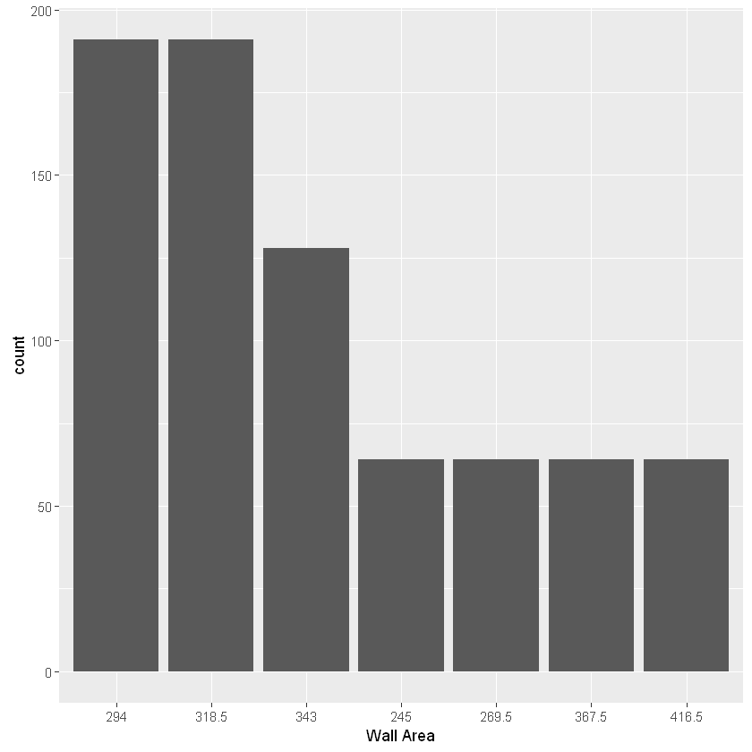

```r
require(ggplot2)
ggplot(Cleansedenergy.ff, aes(x=reorder(Wall.Area,Wall.Area, function(x) -length(x)))) + ## Function shorts the bars
  geom_bar() +
  xlab('Wall Area')
  theme(axis.text.x = element_text(angle = 90, hjust = 1)) ## Theme function for conrol
```

Bar plot clearly shows you that wall area between 294 & 318.5 is most prevalent in the homes.

### Histograms

Histograms are related to bar plots. Histograms are used for numeric variables. Whereas, a bar plot shows the counts of unique categories, a histogram shows the number of data with values in each bin. The bins divide the values of the variable into equal segments. The vertical axis of the histogram shows the count of data values within each bin.

Execute the code in the cell below to create a histogram using the `geom_histogram` function.

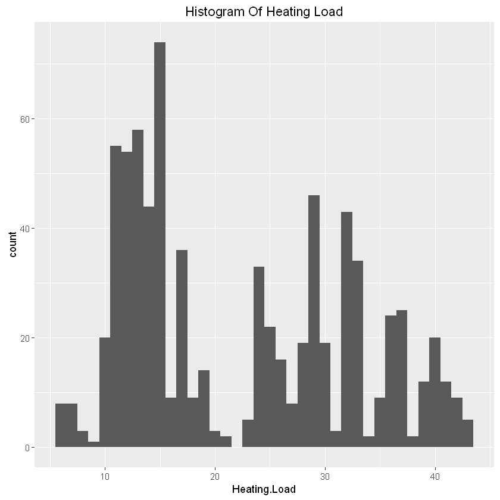

```r
ggplot(Cleansedenergy.ff, aes(Heating.Load)) + geom_histogram(binwidth = 1) +
  ggtitle('Histogram Of Heating Load')
```

The histogram shows Heating.Load with a positive skewed distribution.

### Box plots

Box plots, also known as box and wisker plots, were introduced by John Tukey in 1970. Box plots are another way to visualize the distribution of data values. In this respect, box plots are comparable to histograms, but are quite different in presentation.

A diagram showing the interpretation of a box plot is shown in the figure below.

[figure not shown]

On a box plot the median value is shown with a dark bar. The inner two qartiles of data values are contained within the 'box'. The 'wiskers' enclose the majority of the data, at +/-1.5 times the inter-quartile range. Outliers are shown by symbols beyond the wiskers.

Several box plots can be stacked along an axis. The data are divided using a 'group by' operation, and the box plots for each group are stacked next to each other. In this way, the box plot allows you to display two dimensions of your data set.

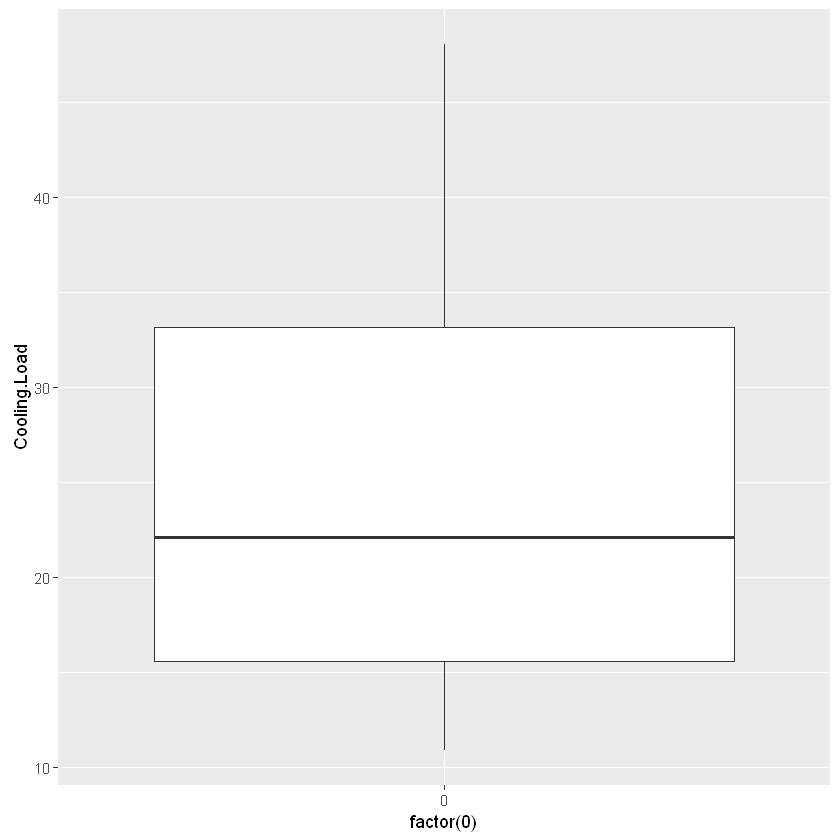

```r
ggplot(Cleansedenergy.ff, aes(x = factor(0), y = Cooling.Load )) + geom_boxplot()
```

Box plots are most useful when the data are subdivided using another variable. In ggolot2 the you can add an x variable of **Overall Height** factor to perform this group by operation. Execute the code below to display the box plots of `Cooling.Load` grouped by the `Overall.Height` variable.

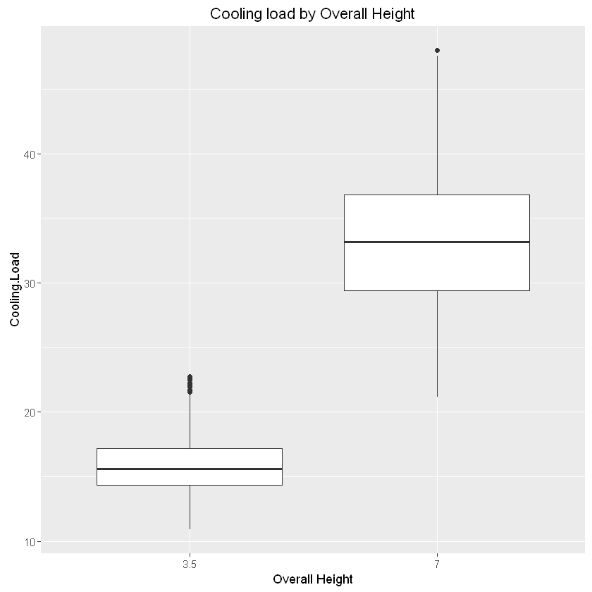

```r
#Create boxplot to compare two variables.
ggplot(Cleansedenergy.ff, aes(x = factor(Overall.Height), y = Cooling.Load)) + geom_boxplot() +
  xlab('Overall Height') + ggtitle('Cooling load by Overall Height')
```

Examine these box plots and note the following:

- The median cooling load of a overall height of 3.5 is considerably less than overall height of 7.
- Overall Height of 3.5 has a lot more outliers as compared to 7 when grouped by cooling load.
- There is no overlap between the interquartile ranges of cooling load distributions of overall height of 3.5 & 7, this would convey that overall height of the house has a strong effect on the cooling load as cooling numbers are dramatically going up with the overall height.

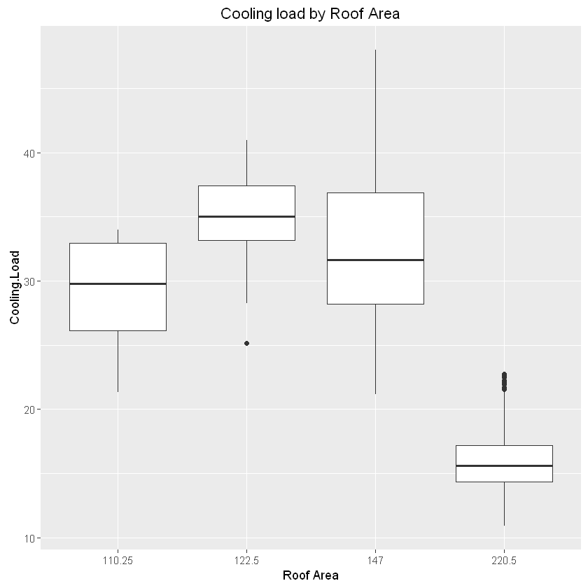

```r
ggplot(Cleansedenergy.ff, aes(x = factor(Roof.Area), y = Cooling.Load)) + geom_boxplot() +
  xlab('Roof Area') + ggtitle('Cooling load by Roof Area')
```

One can see that Roof Area has a negative correlation with cooling loads.

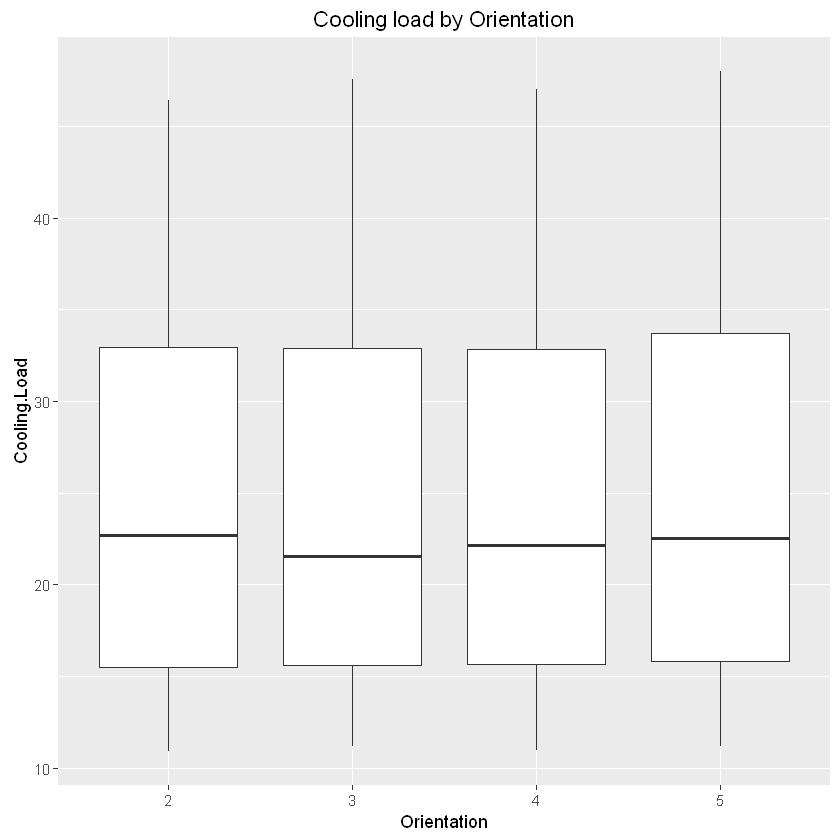

```r
ggplot(Cleansedenergy.ff, aes(x = factor(Orientation), y = Cooling.Load)) + geom_boxplot() +
  xlab('Orientation') + ggtitle('Cooling load by Orientation')
```

One can clearly see that Orientation has no correlation with cooling loads.

### Kernel density estimation plots

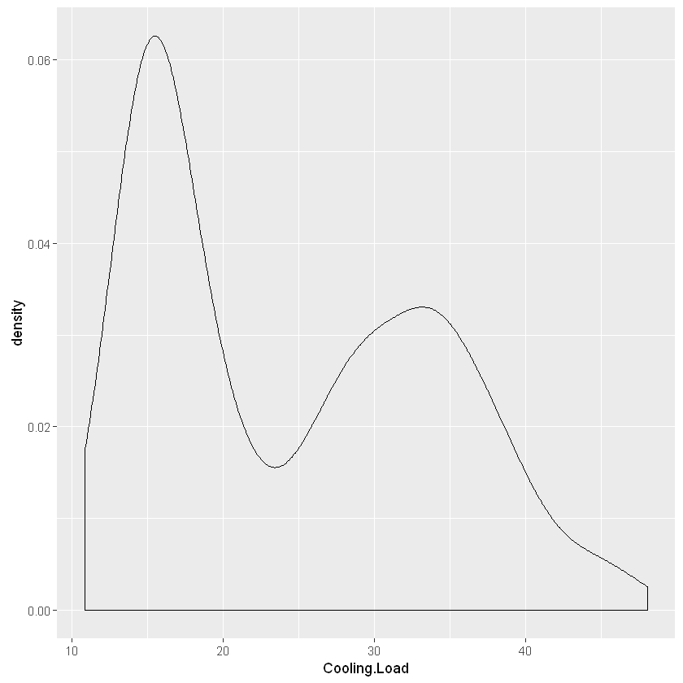

```r
ggplot(Cleansedenergy.ff, aes(Cooling.Load )) + geom_density()
```

### Violin plots

Violine plots are a useful, and relatively new, plot type. The violin plot combines some attributes of a kernal density plot and the box plot. The violin plot shows a pair of symetric kernel density plot. Like a box plot, the violin plot can be conditioned on a categorical (factor) variable.

The code in the cell below creates a violin plot of cooling load, grouped by overall height. Some attributes have been added to show quantiles with the `draw_quantiles` attribute. Additionally, the `trim` attribute adds wiskers to show outliers. Execute this code to create the plot.

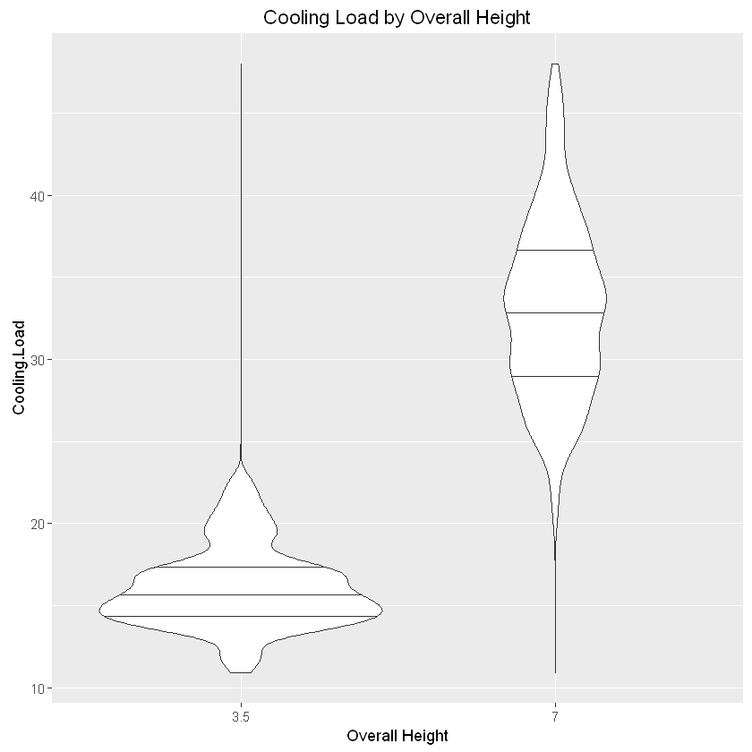

```r
ggplot(Cleansedenergy.ff, aes(x = factor(Overall.Height), y = Cooling.Load)) +
    geom_violin(trim = FALSE, draw_quantiles = c(0.25, 0.5, 0.75)) +
    xlab('Overall Height')  + ggtitle('Cooling Load by Overall Height')
```

This plot clearly shows a thick spread of **Cooling.Load** on the 1st quartile of 3.5 and then goes onto to show a fair share of outliers beyond the 3rd quartile, one can also validate an even spread **Cooling.Load** between 1st and 3rd quartile of 7, with no outliers.

**One would have however expected to see atleast one outlier beyound 3rd Quartile on 7 as seen on the previous bar plot.**

`This would be a question to the professor.`

Given below is a violin plot between cooling load and orientation, we would expect to see no meaningful relationship in this plot.

[figure not shown]

```r
ggplot(Cleansedenergy.ff, aes(x = factor(Orientation), y = Cooling.Load)) +
  geom_violin(trim = FALSE, draw_quantiles = c(0.25, 0.5, 0.75)) +
  xlab('Orientation')  + ggtitle('Cooling Load by Roof Area')
```

As you can see above orientation has no bearing on cooling load.

## Scatter plots

A basic scatter plot shows the relationship between two variables. Points are ploted at the x-y coordinates of each value pair.

Execute the code in the cell below to create a scatter plot of `Overall.Height` on the horizontal axis vs. `Cooling.Load` on the vertical axis.

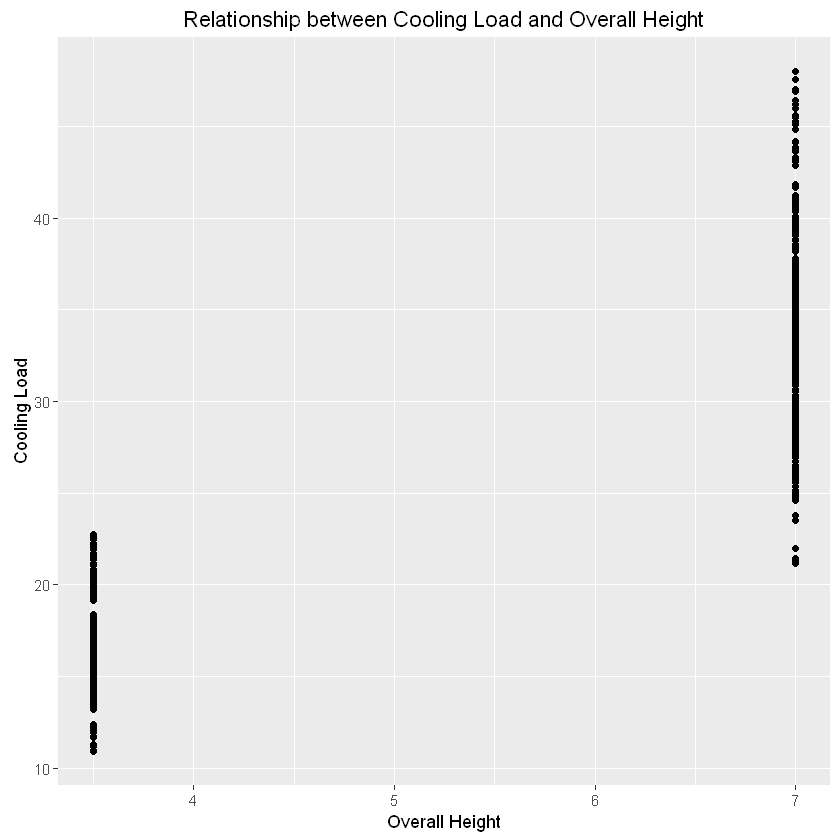

```r
ggplot(Cleansedenergy.ff, aes(x = Overall.Height, y = Cooling.Load)) + geom_point() +
    xlab('Overall Height') + ylab('Cooling Load') +
    ggtitle('Relationship between Cooling Load and Overall Height')
```

The scatter plot shows the relationship between Cooling Load and Overall Height. The relationship clearly shows a higher cooling load for homes with a higher overall height.

### 2D kernel density plot

A 2 dimensional kernel density plot works much like the 1 dimensional version we have already explored. A useful application is to overlay the 2D kernel density plot on a scatter plot. Execute the code below to create the plot.

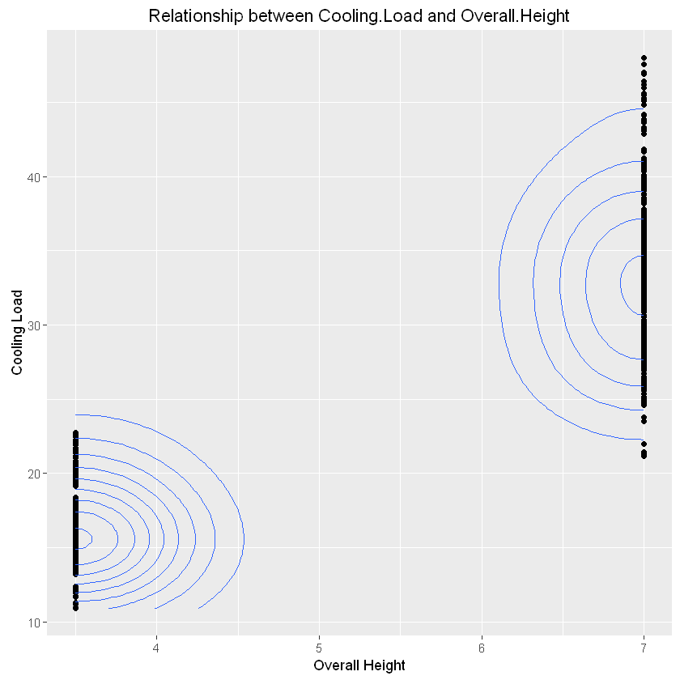

```r
ggplot(Cleansedenergy.ff, aes(Overall.Height, Cooling.Load)) + geom_point() +
    geom_density2d() +
    xlab('Overall Height') + ylab('Cooling Load') +
    ggtitle('Relationship between Cooling.Load and Overall.Height')
```

The 2D kernel density estimate is shown using contours in this case. Other options are available.

The groups of outliers are very prominent.